# Note-bnlearn

Weiquan Luo

Updated by 2021-01-21

### Use of this document

This is a study note for using $bnlearn$ package from the book of Bayesian Networks with Examples in R. For more details on the study material see: http://www.bnlearn.com/book-crc/

### Prerequisite

```r
library(bnlearn)
```

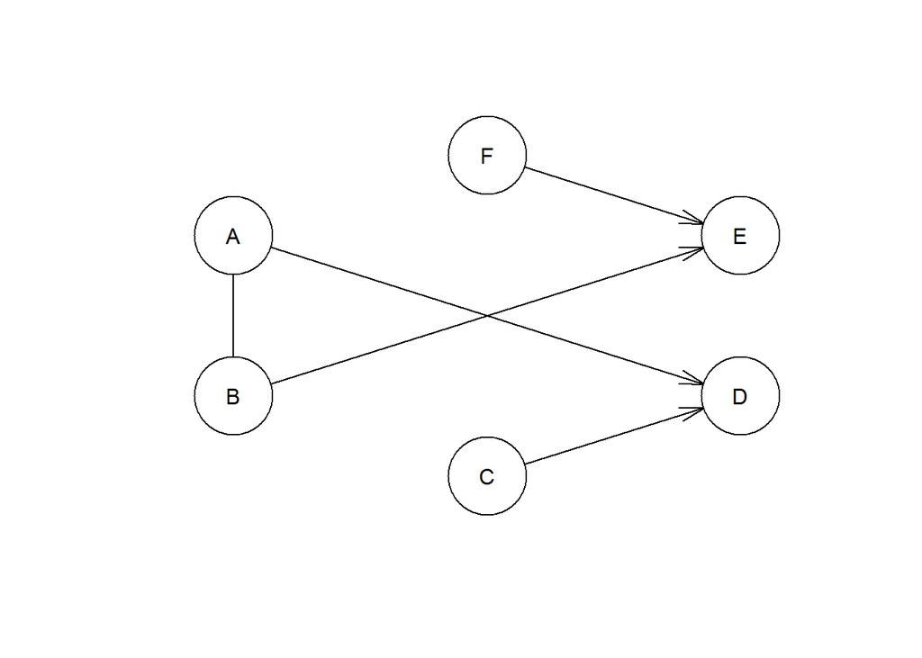

```r
data(learning.test)
res = gs(learning.test)
plot(res)
```

```r
##  the Markov blanket of A.
mb(res, "A")
```

```
## [1] "B" "C" "D"
```

```r
## the neighbourhood of F.
nbr(res, "F")
```

```
## [1] "E"
```

```r
## the arcs in the graph.
arcs(res)
```

```
##      from to
## [1,] "A"  "B"
## [2,] "A"  "D"
## [3,] "B"  "A"
## [4,] "B"  "E"
## [5,] "C"  "D"
## [6,] "F"  "E"
```

```r
## the nodes of the graph.
nodes(res)
```

```
## [1] "A" "B" "C" "D" "E" "F"
```

```r
## the adjacency matrix for the nodes of the graph.
amat(res)
```

```
##   A B C D E F
## A 0 1 0 1 0 0
## B 1 0 0 0 1 0
## C 0 0 0 1 0 0
## D 0 0 0 0 0 0
## E 0 0 0 0 0 0
## F 0 0 0 0 1 0
```

```r
## the parents of D.
parents(res, "D")
```

```
## [1] "A" "C"
```

```r
## the children of A.
children(res, "A")
```

```
## [1] "D"
```

```r
## the root nodes of the graph.
root.nodes(res)
```

```
## [1] "C" "F"
```

```r
## the leaf nodes of the graph.
leaf.nodes(res)
```

```
## [1] "D" "E"
```

```r
## number of parameters of the Bayesian network.
res = set.arc(res, "A", "B")
nparams(res, learning.test)
```

```
## [1] 41
```

Equivalent name to Bayesian network:

- Bayes network
- belief network
- decision network
- Bayes(ian) model
- probabilistic directed acyclic graphical model

BNs are used as expert systems, because they formalise the knowledge possessed by one or more experts in the relevant fields. The R library $bnlearn$ will be used in this note. Some important notes for BN:

- A Bayesian network is a directed acyclic graph (DAG) that effectively expresses independence assertions among random variables.
- The parents of a node X are those variables on which X directly depends.
- Consideration of causal dependencies among variables typically help in constructing a Bnet.

Concepts of Independence and Conditional Probability:

- `Bayes' theorem`: P(A|B) = P(B|A)P(A)/P(B)
- `Absolute Independent`: P(A,B) = P(A)P(B), it is powerful but when you model a particular domain, it is rare.
- `Marginal Independence`: P(A|X) = P(A), when your knowledge of Y's value does not affect your belief in the value of X
- `conditional independence`: P(A|X,Y) = P(A|Y), weaker form of independence, Sometimes, two variables might not be marginally independent. However, they become independent after we observe some third variable, often reduces the size of the representation of the joint distribution (DAG)
- `chain rule`: apply to P(A,B,C) result P(A)P(A|B)P(C|B,A), then Simplify according to marginal & conditional independence

# 1. Introduction to Bayesian Networks

In the sections 1.1 and 1.2, we assumed that the DAG underlying the BN is known. In other words, we rely on prior knowledge on the phenomenon we are modelling to decide which arcs are present in the graph and which are not. As an example in section 1.3, we will learn the parameters of the local distributions from an observed sample.

In section 1.4, we will learn the structure of the DAG itself.

## 1.1 Graphical representation

- `directed acyclic graphs` (DAGs): sequences of arcs are said to form a path leading from one variable to the other distinct variable (A to… to B, not A to… to A)
- `Direct dependence`: the relationships are represented as arcs between pairs of variables
- `parent`: The node at the tail of the arc
- `child`: The node at the head of the arc
- `root`: the node without any parents.

## 1.2 Three ways of creating DAG

The process of creating DAG is to encode the desired direct dependencies.

`bn`: The Objects of class used to describe DAGs in $bnlearn$. The following functions are commonly use to investigate and manipulate bn objects.

- `nodes()`: show all nodes existing in a DAG object
- `arcs()`: show all arcs existing in a DAG object
- `set.arc()`: set a relationship (arc) in a DAG object
- `modelstring()`: shows the representation of the graph structure in term of a product of conditional probabilities,

```r
dag <- empty.graph(nodes = c("A", "S", "E", "O", "R", "T")) # empty graph,
dag <- set.arc(dag, from = "A", to = "E")
dag <- set.arc(dag, from = "S", to = "E")
dag <- set.arc(dag, from = "E", to = "O")
dag <- set.arc(dag, from = "E", to = "R")
dag <- set.arc(dag, from = "O", to = "T")
dag <- set.arc(dag, from = "R", to = "T")

dag2 <- empty.graph(nodes = c("A", "S", "E", "O", "R", "T"))
arc.set <- matrix(c("A", "E",
                    "S", "E",
                    "E", "O",
                    "E", "R",
                    "O", "T",
                    "R", "T"),
             byrow = TRUE, ncol = 2,
             dimnames = list(NULL, c("from", "to")))
arcs(dag2) <- arc.set

dag3 <- model2network("[A][S][E|A:S][O|E][R|E][T|O:R]")

all.equal(dag2,dag)
```

```
## [1] TRUE
```

```r
all.equal(dag2,dag3)
```

```
## [1] TRUE
```

```r
class(dag)
```

```
## [1] "bn"
```

## 1.2 Probabilistic representation

`bn.fit` : The Objects of class used to describe BNs in $bnlearn$. They include information of all the conditional probability about both the DAG (such as the parents and the children of each node) and the local distributions (their parameters, ie. `cpt` conditional probablity table in the following).

- `custom.fit()`: generate a object of `bn.fit` class by entering the dag object with `bn` class and `cpt` list.
- `nparms()`: show the numbers of the parameter sets of the local distributions.
- `coef()`: extract the conditional probablity for a node useing `$`.

```r
# discret case
A.lv <- c("young", "adult", "old")
S.lv <- c("M", "F")
E.lv <- c("high", "uni")
O.lv <- c("emp", "self")
R.lv <- c("small", "big")
T.lv <- c("car", "train", "other")
A.prob <- array(c(0.30, 0.50, 0.20),
                dim = 3,
                dimnames = list(A = A.lv))
S.prob <- array(c(0.60, 0.40),
                dim = 2,
                dimnames = list(S = S.lv))
O.prob <- array(c(0.96, 0.04, 0.92, 0.08),
                dim = c(2, 2),
                dimnames = list(O = O.lv, E = E.lv))
R.prob <- array(c(0.25, 0.75, 0.20, 0.80),
                dim = c(2, 2),
                dimnames = list(R = R.lv, E = E.lv))
R.prob <- matrix(c(0.25, 0.75, 0.20, 0.80), ncol = 2,
                 dimnames = list(R = R.lv, E = E.lv))
E.prob <- array(c(0.75, 0.25, 0.72, 0.28, 0.88, 0.12, 0.64, 0.36, 0.70, 0.30, 0.90, 0.10),
                dim = c(2, 3, 2),
                dimnames = list(E = E.lv, A = A.lv, S = S.lv))
T.prob <- array(c(0.48, 0.42, 0.10, 0.56, 0.36, 0.08, 0.58, 0.24, 0.18, 0.70, 0.21, 0.09),
                dim = c(3, 2, 2),
                dimnames = list(T = T.lv, O = O.lv, R = R.lv))
cpt <- list(A = A.prob, S = S.prob, E = E.prob, O = O.prob,
        R = R.prob, T = T.prob)
bn <- custom.fit(dag, cpt)
class(bn)
```

```
## [1] "bn.fit"      "bn.fit.dnet"
```

```r
R.cpt <- coef(bn$R)
```

## 1.3 Estimating the Parameters

In the exmaple of survey dataset, and of discrete BNs in general, the parameters to estimate are the conditional probabilities in the local distributions. They can be estimated with the corresponding empirical frequencies in the data set by using the following function:

`bn.fit()`: estimate the conditional probabilities

- `method = "mle"`: maximum likelihood estimates.
- `method = "bayes"`: Bayesian setting with using their posterior distributions.
  - `iss`: Short for imaginary sample size (also known as equivalent sample size), determines how much weight is assigned to the prior distribution compared to the data when computing the posterior.The value of iss is typically chosen to be small, usually between 1 and 15, to allow the prior distribution to be easily dominated by the data.Increasing the value of iss makes the posterior distribution more and more flat, pushing it towards the uniform distribution used as the prior.

```r
survey <- read.table("R Code and Data Files/survey.txt", header = TRUE)
head(survey)
```

```
##       A     R    E   O S     T
## 1 adult   big high emp F   car
## 2 adult small  uni emp M   car
## 3 adult   big  uni emp F train
## 4 adult   big high emp M   car
## 5 adult   big high emp M   car
## 6 adult small high emp F train
```

```r
options(digits = 3)
bn.mle <- bn.fit(dag, data = survey, method = "mle")
prop.table(table(survey[, c("O", "E")]), margin = 2)
```

```
##       E
## O        high    uni
##   emp  0.9808 0.9259
##   self 0.0192 0.0741
```

## 1.4 Learning the DAG Structure

The structure of the DAG may identify which nodes are directly related to the target of the analysis and may therefore be used to improve the process. Now, we will put our attention to the two classes of statistical criteria used by those algorithms to evaluate DAGs:

- Conditional independence tests: focus on the presence of individual arcs.
- network scores: focus on the DAG as a whole

As a result, every node is independent from its non-descendants given it parents.

- `arc.strength()`: measure the strength of the probabilistic dependence corresponding to each arc by removing that particular arc from the graph and quantifying the change with some probabilistic criterion.(tend to remove the arc with high strength)
  - `criterion = x2`test is for the to node to be independent from the from node conditional on the remaining parents of to. The reported strength is the resulting p-value.
  - `criterion = BIC`: particular, removing an arc causes a marked increase in the BIC score, which is consistent with the high p-value

### 1.4.1 Conditional Independence Tests

Since each arc encodes a probabilistic dependence, conditional independence tests can be used to assess whether that probabilistic dependence is supported by the data.

Given a DAG A->B->C, the null hypothesis is that C is probabilistically independent from A conditional on C’s parents, B. If the null hypothesis is rejected, the arc (A->C) can be considered in the DAG. The null hypothesis is rejected for large values of the test statistics, which increase with the strength of the conditional dependence between the variables. If the null hypothesis (of conditional independence) is rejected, the arc can be considered for inclusion in the DAG.

We can test this null hypothesis by adapting either the log-likelihood ratio G^2 or Pearson's X^2 to test for conditional independence instead of marginal independence.

`ci.test(A, B, between)`: Conditional Independence Tests for A and B. (rejection -> high test statistics -> dependent -> inclusion)

- `test = "mi"`:implementsThe G2 test, which is equivalent to the mutual information test from information theory.
- `test = "x2"`: Pearson' X2 test

```r
ci.test("T", "E", c("O", "R"), test = "mi", data = survey)
```

```
##
##  Mutual Information (disc.)
##
## data:  T ~ E | O + R
## mi = 10, df = 8, p-value = 0.3
## alternative hypothesis: true value is greater than 0
```

```r
ci.test("T", "E", c("O", "R"), test = "x2", data = survey)
```

```
##
##  Pearson's X^2
##
## data:  T ~ E | O + R
## x2 = 8, df = 8, p-value = 0.4
## alternative hypothesis: true value is greater than 0
```

```r
ci.test("T", "O", "R", test = "x2", data = survey)
```

```
##
##  Pearson's X^2
##
## data:  T ~ O | R
## x2 = 4, df = 4, p-value = 0.4
## alternative hypothesis: true value is greater than 0
```

### 1.4.2 Network Scores

Network scores are goodness-of-fit statistics measuring how well the DAG mirrors the dependence structure of the data. Using either of these scores it is possible to compare different DAGs and investigate which fits the data better. Scores can also be used to compare completely different networks, unlike conditional independence tests.

- `type = "bic"`: the Bayesian Information criterion
- `type = "bde"`: Bayesian Dirichlet equivalent uniform(BDeu) posterior probability of the DAG associated with a uniform prior over both the space of the DAGs and of the parameters; For small values of iss or large observed samples, log BDe and BIC scores yield similar values.

```r
library(bnlearn)
score(dag, data = survey, type = "bic")
```

```
## [1] -2013
```

```r
dag4 <- set.arc(dag, from = "E", to = "T")
nparams(dag4, survey)
```

```
## [1] 29
```

```r
score(dag4, data = survey, type = "bic")
```

```
## [1] -2033
```

```r
score(dag, data = survey, type = "bde", iss = 10)
```

```
## [1] -1998
```

`hc`: There are one of the several algorithms, which search for the DAG that maximises a given network score;

```r
learned <- hc(survey)
modelstring(learned)
```

```
## [1] "[R][E|R][T|R][A|E][O|E][S|E]"
```

```r
score(learned, data = survey, type = "bic")
```

```
## [1] -1998
```

```r
score(learned, data = survey, type = "bde")
```

```
## [1] -2002
```

## 1.5 Using Discrete BNs

A BN can be used for inference through either its DAG or the set of local distributions. The process of answering questions using either of these two approaches is known in computer science as `querying`.

If we consider a BN as an expert system, we can imagine asking it questions (i.e., querying it) as we would a human expert and getting answers out of it. For example:

- they may take the form of probabilities associated with an event under specific conditions, leading to conditional probability queries;
- they may validate the association between two variables after the influence of other variables is removed, leading to conditional independence queries;
- they may identify the most likely state of one or more variables, leading to most likely explanation queries.

The two most common types of inference are :

- `conditional probability queries`: investigate the distribution of one or more variables under non-trivial conditioning,
- `most likely explanation queries`: look for the most likely outcome of one or more variables (again under non-trivial conditioning).

### 1.5.1 Using the DAG Structure

Using the DAG we saved in dag, we can investigate whether a variable is associated to another, essentially asking a `conditional independence query`.

- `Conditioning` on Z: is equivalent to fixing the values of its elements,
- `d-separation`: (also called directed separation) the X and Y are separated by Z, which we denote with X_||_Y | Z. The three fundamental connections shown in d-separation:
  - `serial connection`: both arcs have the same direction and follow one after the other;
  - `divergent connection`: the two arcs have divergent directions from a central node;
  - `convergent connection`: the two arcs converge to a central node. node. When there is no arc linking the two parents convergent connections are called v-structures.

Both direct and indirect associations between two variables can be read from the DAG by checking whether they are connected in some way. Conditioning on a particular node can also make two other nodes dependent when they are marginally independent.

`dsep()`: investigate whether two nodes in a bn object are d-separated. `path()`: shows whether there is a path leading from A to B

```r
dsep(dag, x = "S", y = "R")
```

```
## [1] FALSE
```

```r
dsep(dag, x = "O", y = "R")
```

```
## [1] FALSE
```

```r
path(dag, from = "S", to = "R")
```

```
## [1] TRUE
```

### 1.5.2 Using the Conditional Probability Tables

More complex queries require the use of the local distributions. Depending on the query, the simulation can be either direct or constrained. Function `rbn` implements the former, while `cpquery` and `cpdist` provide an easy access to both options.

#### 1.5.2.1 Exact inference

```r
library(gRain)
```

#### 1.5.2.2 Approximation inference

An alternative approach to inference is to use Monte Carlo simulations to randomly generate observations from the BN. While this approach is computationally expensive, it allows for complex specifications of the evidence and scales better to BNs including a large number of nodes.

`Rejection sampling`: we generate random independent observations from the BN, then we count how many match the evidence we are conditioning on and how many of those observations also match the event whose probability we are computing; the estimated conditional probability is the ratio between the latter and the former.

- `cpquery()`: returns the probability of a specific event given some evidence;
  - `n`: the number of random observations, default `n = 5000`. To improve the quality of the approximation, cheng to `n = 1000000`. However, increasing precision in this way has several drawbacks: answering the query takes much longer, and the precision may still be low if evidence has a low probability.
  - `method = "lw"`: Likelihood weighting generates random observations in such a way that all of them match the evidence, and re-weights them appropriately when computing the conditional probability for the query.

```r
cpquery(bn, event = (S == "M") & (T == "car"),
          evidence = (E == "high"))
```

```
## [1] 0.34
```

```r
cpquery(bn, event = (S == "M") & (T == "car"),
            evidence = (E == "high"), n = 10^6)
```

```
## [1] 0.343
```

```r
set.seed(567)

cpquery(bn, event = (S == "M") & (T == "car"),
            evidence = list(E = "high"), method = "lw")
```

```
## [1] 0.342
```

```r
set.seed(123)
cpquery(bn, event = (S == "M") & (T == "car"),
  evidence = ((A == "young") & (E == "uni")) | (A == "adult"))
```

```
## [1] 0.335
```

```r
SxT <- cpdist(bn, nodes = c("S", "T"),
         evidence = (E == "high"))
head(SxT)
```

```
##   S     T
## 1 M   car
## 2 M   car
## 3 M   car
## 4 M other
## 5 M   car
## 6 F other
```

## 1.6 Plotting BNs

### 1.6.1 Plotting DAGs

- `graphviz.plot()`: Highlighting particular nodes and arcs in a DAG, for instance to mark a path or the nodes involved in a particular query,

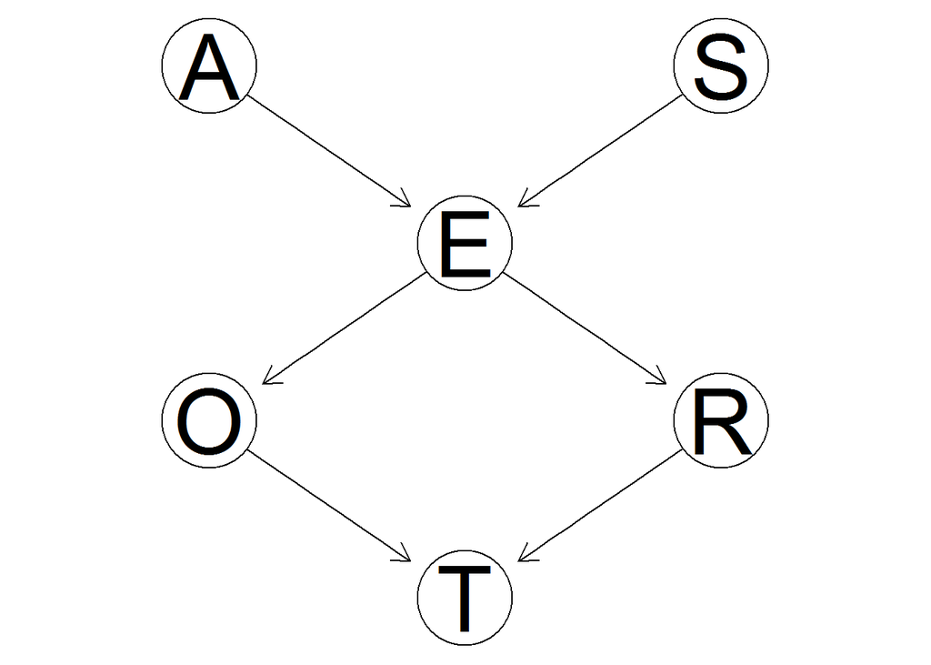

```r
library(Rgraphviz)
graphviz.plot(dag)
```

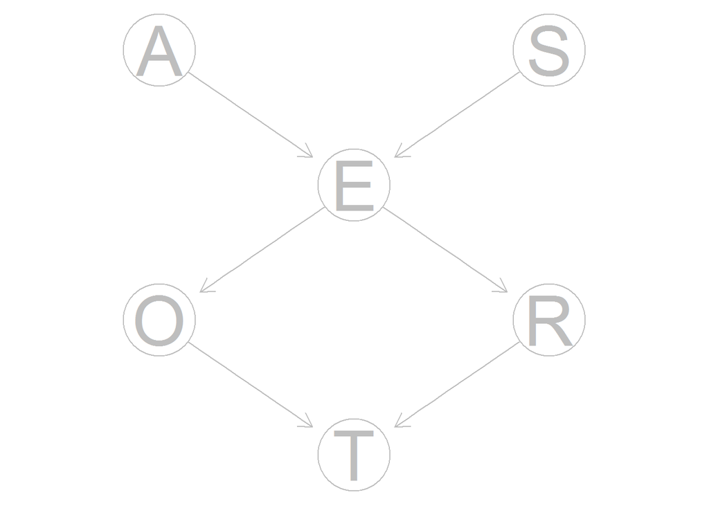

```r
hlight <- list(nodes = nodes(dag), arcs = arcs(dag),
                  col = "grey", textCol = "grey")
pp <- graphviz.plot(dag, highlight = hlight)
```

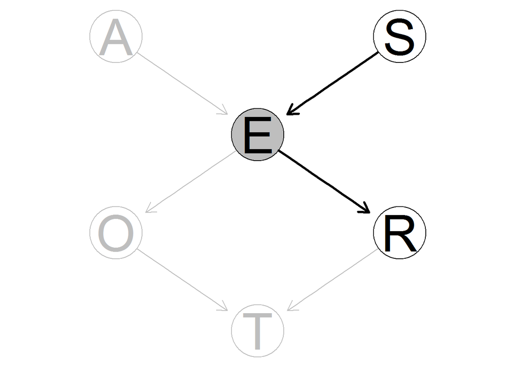

```r
edgeRenderInfo(pp) <-
  list(col = c("S~E" = "black", "E~R" = "black"),
       lwd = c("S~E" = 3, "E~R" = 3))
nodeRenderInfo(pp) <-
  list(col = c("S" = "black", "E" = "black", "R" = "black"),
    textCol = c("S" = "black", "E" = "black", "R" = "black"),
    fill = c("E" = "grey"))
renderGraph(pp)
```

### 1.6.2 Plotting Conditional Probability Distributions

As can be seen from the formula, we are plotting Prob for each level of Travel given the Evidence.

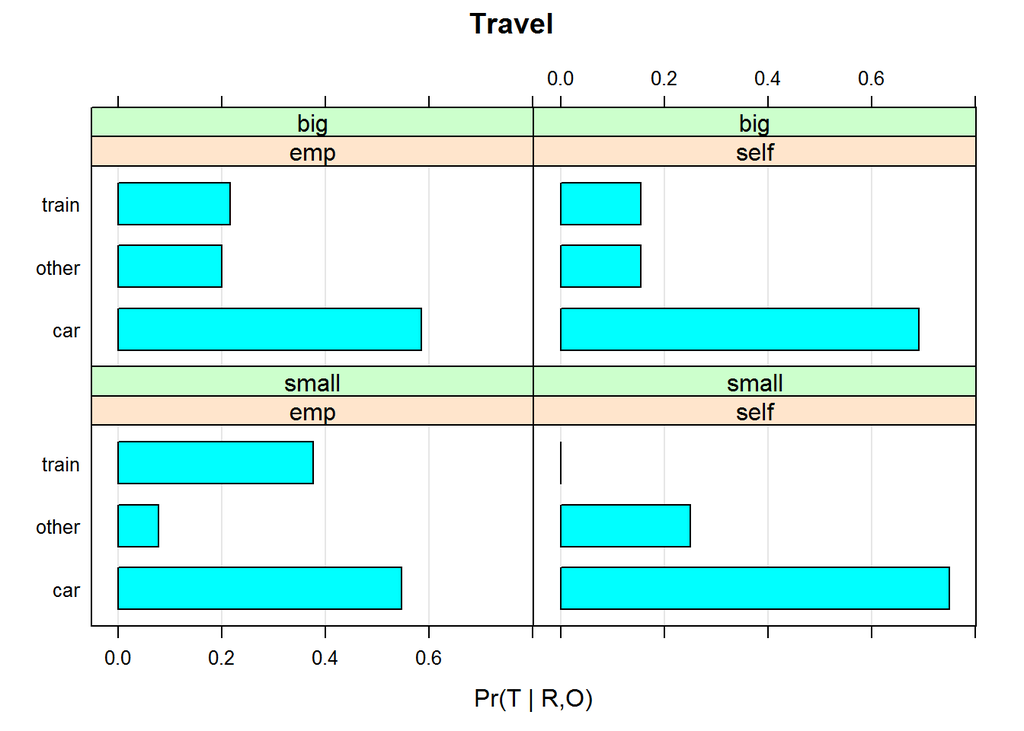

```r
library(lattice)
bn.fit.barchart(bn.mle$T, main = "Travel",
  xlab = "Pr(T | R,O)", ylab = "")
```

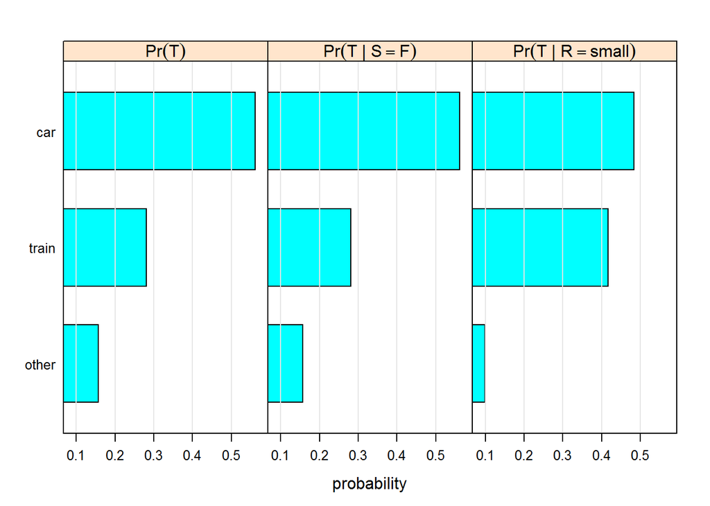

```r
Evidence <-
  factor(c(rep("Unconditional",3), rep("Female", 3),
           rep("Small City",3)),
         levels = c("Unconditional", "Female", "Small City"))
Travel <- factor(rep(c("car", "train", "other"), 3),
           levels = c("other", "train", "car"))
distr <- data.frame(Evidence = Evidence, Travel = Travel,
           Prob = c(0.5618, 0.2808, 0.15730, 0.5620, 0.2806,
                    0.1573, 0.4838, 0.4170, 0.0990))

barchart(Travel ~ Prob | Evidence, data = distr,
   layout = c(3, 1), xlab = "probability",
   scales = list(alternating = 1, tck = c(1, 0)),
   strip = strip.custom(factor.levels =
     c(expression(Pr(T)),
       expression(Pr({T} * " | " * {S == F})),
       expression(Pr({T} * " | " * {R == small})))),
   panel = function(...) {
     panel.barchart(...)
     panel.grid(h = 0, v = -1)
   })
```

# 2. Gaussian Bayesian networks

The classic continuous case is linear Gaussian Bayesian networks, which rest on the following assumptions:

- every node follows a normal distribution;
- nodes without any parent, known as root nodes, are described by the respective marginal distributions;
- the conditioning effect of the parent nodes is given by an additive linear term in the mean, and does not affect the variance. In other words, each node has a variance that is specific to that node and does not depend on the values of the parents;
- the local distribution of each node can be equivalently expressed as a Gaussian linear model which includes an intercept and the node's parents as explanatory variables, without any interaction term.

In section 2.1 and 2.2, we will briefly introduce the GBN. In section 2.3, we will tackle the estimation of the parameters of a GBN assuming its structure (i.e., the DAG) is completely known.

```r
library(bnlearn)
```

## 2.1 Graphical Representation

```r
# continues case: Gaussian Bayesian networks
dag.bnlearn <- model2network("[G][E][V|G:E][N|V][W|V][C|N:W]")

disE <- list(coef = c("(Intercept)" = 50), sd = 10)
disG <- list(coef = c("(Intercept)" = 50), sd = 10)
disV <- list(coef = c("(Intercept)" = -10.35534,
                      E = 0.70711, G = 0.5), sd = 5)
disN <- list(coef = c("(Intercept)" = 45, V = 0.1),
             sd = 9.949874)
disW <- list(coef = c("(Intercept)" = 15, V = 0.7),
             sd = 7.141428)
disC <- list(coef = c("(Intercept)" = 0, N = 0.3, W = 0.7),
             sd = 6.25)
dis.list = list(E = disE, G = disG, V = disV, N = disN,
                W = disW, C = disC)
gbn.bnlearn <- custom.fit(dag.bnlearn, dist = dis.list)
```

## 2.2 Probabilistic Representation

```r
nano <- nodes(dag.bnlearn)
for (n1 in nano) {
  for (n2 in nano) {
    if (dsep(dag.bnlearn, n1, n2))
      cat(n1, "and", n2, "are independent.\n")
  }#FOR
}#FOR
```

```
## E and G are independent.
## G and E are independent.
```

```r
for (n1 in nano[nano != "V"]) {
  for (n2 in nano[nano != "V"]) {
    if (n1 < n2) {
      if (dsep(dag.bnlearn, n1, n2, "V"))
        cat(n1, "and", n2, "are independent given V.\n")
    }#THEN
  }#FOR
}#FOR
```

```
## C and E are independent given V.
## C and G are independent given V.
## E and N are independent given V.
## E and W are independent given V.
## G and N are independent given V.
## G and W are independent given V.
## N and W are independent given V.
```

```r
bnlearn::path(dag.bnlearn, from = "E", to = "C")
```

```
## [1] TRUE
```

In the following, we will supplement $bnlearn$ with another R package, $rbmn$ (short for reseaux bayesiens multinormaux), focusing specifically on GBNs. $rbmn$ provides a function to convert `bn.fit` objects into `mn` object.

The parameters of that multivariate normal distribution,`mn`, can be derived numerically form a `gbn`:

- `nbn`: Normal Bayesian networks describe the GBN by
  - the local distributions, which is natural considering how BNs are defined.
  - `print8nbn`: print a `nbn` object
- `gema`: the GBN is described by two generating matrices such that $mu+li*E=$ has the same distribution as the input `nbn`
  - `mu`: a vector of expectations
  - `li`: a matrix (E1, E2,…, E6 are independent and identically distributed N(0, 1) Gaussian variables.) to be multiplied by a N(0, 1) white noise.
  - `print8gema`: print a `gema` object
- `mn`: The multivariate normal distribution object is a simple list holding:
  - `mu`: vector of the marginal expectations
  - `s.d.`: standard deviation
  - the rest of the result: correlation matrix.
  - `print8mn`: print a `mn` object

```r
library(rbmn)
```

```r
# normal Bayesian network
gbn.rbmn <- bnfit2nbn(gbn.bnlearn)
gema.rbmn <- nbn2gema(gbn.rbmn)
mn.rbmn <- gema2mn(gema.rbmn)
print8nbn(gbn.rbmn)
```

```
## =====Nodes===[parents]   = Exp. (sd.dev)
## -----------------------------------------------
## ---------E---[-]  = 50  (10)
## ---------G---[-]  = 50  (10)
## ---------V---[E,G]  = -10.355 + 0.707*E + 0.5*G  (5)
## ---------W---[V]  = 15 + 0.7*V  (7.141)
## ---------N---[V]  = 45 + 0.1*V  (9.95)
## ---------C---[N,W]  = 0.3*N + 0.7*W  (6.25)
```

```r
print8gema(gema.rbmn)
```

```
##   mu     E1   E2  E3   E4   E5   E6
## E 50 10.000  0.0 0.0 0.00 0.00 0.00
## G 50  0.000 10.0 0.0 0.00 0.00 0.00
## V 50  7.071  5.0 5.0 0.00 0.00 0.00
## W 50  4.950  3.5 3.5 7.14 0.00 0.00
## N 50  0.707  0.5 0.5 0.00 9.95 0.00
## C 50  3.677  2.6 2.6 5.00 2.98 6.25
```

```r
print8mn(mn.rbmn)
```

```
##   mu s.d.   C.E  C.G   C.V   C.W   C.N   C.C
## E 50   10 1.000 0.00 0.707 0.495 0.071 0.368
## G 50   10 0.000 1.00 0.500 0.350 0.050 0.260
## V 50   10 0.707 0.50 1.000 0.700 0.100 0.520
## W 50   10 0.495 0.35 0.700 1.000 0.070 0.721
## N 50   10 0.071 0.05 0.100 0.070 1.000 0.349
## C 50   10 0.368 0.26 0.520 0.721 0.349 1.000
```

(see section 2.5.1 exact inference for more analysis)

## 2.3 Estimating the Parameters

To tackel the estimation of the paramethers o fa GBN assuming its structure is completely known, we generate the dataframe from the dag `bgn.bnlearn` called `cropdata1` to find the correlation coefficients with using `bn.fit()` as same as in the discret case.

`lm`: The parameter estimates produced by lm are the same maximum likelihood estimates we obtained from bn.fit. However, it may still be convenient to use lm due to its flexibility in dealing with missing values and the possibility of including weights in the model.

```r
# small sample
set.seed(4567)
cropdata1 <- rbn(gbn.bnlearn, n = 200)
# big sample
set.seed(1234)
cropdata2 <- rbn(gbn.bnlearn, n = 20000)
dim(cropdata1)
```

```
## [1] 200   6
```

```r
round(head(cropdata1), 2)
```

```
##      C    E    G    N    V    W
## 1 48.8 51.5 42.6 54.1 43.0 42.0
## 2 48.9 73.4 41.0 60.1 65.3 49.0
## 3 67.0 71.1 52.5 51.6 63.2 62.0
## 4 37.8 49.3 56.1 49.0 47.8 38.8
## 5 55.3 49.3 63.5 54.6 60.6 56.7
## 6 56.1 48.7 66.0 44.0 55.5 52.4
```

```r
est.para <- bn.fit(dag.bnlearn, data = cropdata1)
est.para$C <- lm(C ~ N + W, data = cropdata1)
```

## 2.4 Learning the DAG Structure:

cases, if sufficient data are available, we can hope that a statistical procedure may help us in determining a small set of conditional dependencies to translate into a sparse BN.

### 2.4.1 Conditional Independence Tests

To consider the null hypothesis that A may be independent from B given C, the most common is the exact test for partial correlations.

- `partial correlations`: measures the degree of association between two random variables, with the effect of a set of controlling random variables removed. If we are interested in finding whether or to what extent there is a numerical relationship between two variables of interest, using their correlation coefficient will give misleading results if there is another confounding variable that is numerically related to both variables of interest.

To test for conditional independence between two variables, first, we need to compute the correlation matrix for C, W and N.Then we compute the inverse `invcor` of cormat with the `cor2pcor()` function from package $corpcor$, which works even if the input matrix is not full rank. Finally, use `ci.test()` to run the test as in the discret case. As the result:

- `t ~= 0`:the tested variables are conditionally independent;
- large values, either positive or negative, are indicative of the presence and of the direction of the conditional dependence.

```r
library(corpcor)
```

```r
cormat <- cor(cropdata1[, c("C", "W", "N")])
invcor <- cor2pcor(cormat)
dimnames(invcor) <- dimnames(cormat)
invcor
```

```
##       C      W      N
## C 1.000  0.707  0.383
## W 0.707  1.000 -0.288
## N 0.383 -0.288  1.000
```

```r
ci.test("C", "W", "N", test = "cor", data = cropdata1)
```

[output not shown]

sample size affect the DAGs

```r
dim(cropdata1)
```

```
## [1] 200   6
```

```r
stru1 <- iamb(cropdata1, test = "cor")
wl <- matrix(c("V", "N"), ncol = 2)
wl
```

```
##      [,1] [,2]
## [1,] "V"  "N"
```

```r
stru2 <- iamb(cropdata1, test = "cor", whitelist = wl)
all.equal(dag.bnlearn, stru2)
```

```
## [1] TRUE
```

```r
dim(cropdata2)
```

```
## [1] 20000     6
```

```r
stru3 <- iamb(cropdata2, test = "cor")
all.equal(dag.bnlearn, stru3)
```

```
## [1] TRUE
```

### 2.4.2 Network Scores

```r
# score(dag.bnlearn, data = cropdata2, type = "bic-g")
# score(dag.bnlearn, data = cropdata2, type = "bge")
```

## 2.5 Using Gaussian Bayesian Networks

BNs can be investigated from two different points of view: either limiting ourselves to the DAG or using the associated local distributions. DAG properties are independent from the distributional assumptions of the BN. Therefore, nothing has to be added to exact inference for GBN

### 2.5.1 Exact Inference

`condi4joint` in $rbmn$ can be used to obtain

- the conditional joint distribution of one or more nodes when the values of the others are fixed.
- conditional distribution of C given an arbitrary value of V simply not fixing V, and results $C|V \sim N(mu.C + rho * V, gmma)$. not dependent on V if $rho = 0$

```r
print8mn(condi4joint(mn.rbmn, par = "C", pour = "V", x2 = 80))
```

```
##     mu s.d.
## C 65.6 8.54
```

```r
unlist(condi4joint(mn.rbmn, par = "C", pour = "V", x2 = NULL))
```

```
##  mu.C   rho gamma
## 24.00  0.52 72.96
```

### 2.5.2 Approximate Inference

Two ways of query:

- `cpdist` generates random samples conditional on the evidence using the method specified in the method argument. We can condition on `evidence`:
  - a number: Since a single value always has probability 0, we need advanced simulation approaches with `method = "lw"` to avoid conditioning on a single value for one or more variables.
  - an interval: no spacial need.
- `cpquery` estimates the conditional probability of event given evidence using the `method` specified in the method argument.

```r
head(cpdist(gbn.bnlearn, nodes = c("V"), evidence = list(G = 10, E = 90), method = "lw"))
```

```
##      V
## 1 66.9
## 2 62.8
## 3 57.4
## 4 62.8
## 5 72.8
## 6 51.1
```

```r
head(cpdist(gbn.bnlearn, nodes = c("C", "N", "W"), evidence = (C > 80)))
```

```
##      C    N    W
## 1 82.1 59.6 57.8
## 2 80.8 38.8 78.3
## 3 82.0 73.5 65.3
## 4 83.4 61.7 87.1
## 5 80.7 66.4 68.7
## 6 81.5 50.2 80.3
```

## 2.6 Plotting Gaussian Bayesian Networks

### 2.6.1 Ploting DAGs

same to section 1.6.1 Plotting DAGs

### 2.6.2 Plotting Conditional Probability Distributions

$bnlearn$ does not provide any function to plot local probability distributions in GBNs, unlike the `bn.fit.barchart` function available for discrete BNs. The reason is that:

- while the parents of a node in a discrete BN have a finite number of configurations, which are trivial to enumerate and plot.
- the parents of a node in a GBN are defined over $\mathbb{R}$ and the corresponding local distribution is very difficult to plot effectively.

However, some of common diagnostic plots for linear regression models are available:

- `bn.fit.qqplot`: a quantile-quantile plot of the residuals;
- `bn.fit.histogram`: a histogram of the residuals, with their theoretical normal density superimposed;
- `bn.fit.xyplot`: a plot of the residuals against the fitted values.

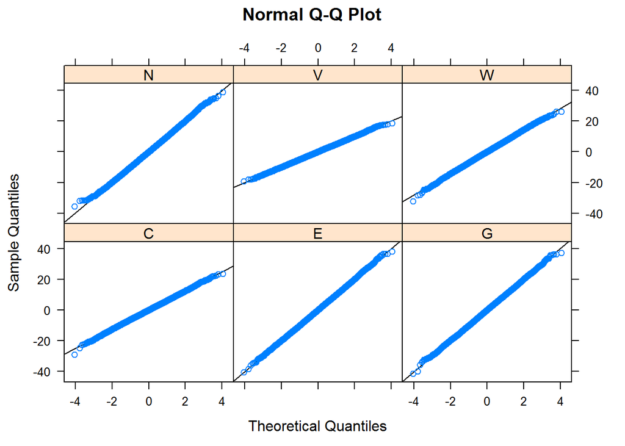

```r
# create bn.fit object
gbn.fit <- bn.fit(dag.bnlearn, cropdata2)
# all variale qqplot
bn.fit.qqplot(gbn.fit)
```

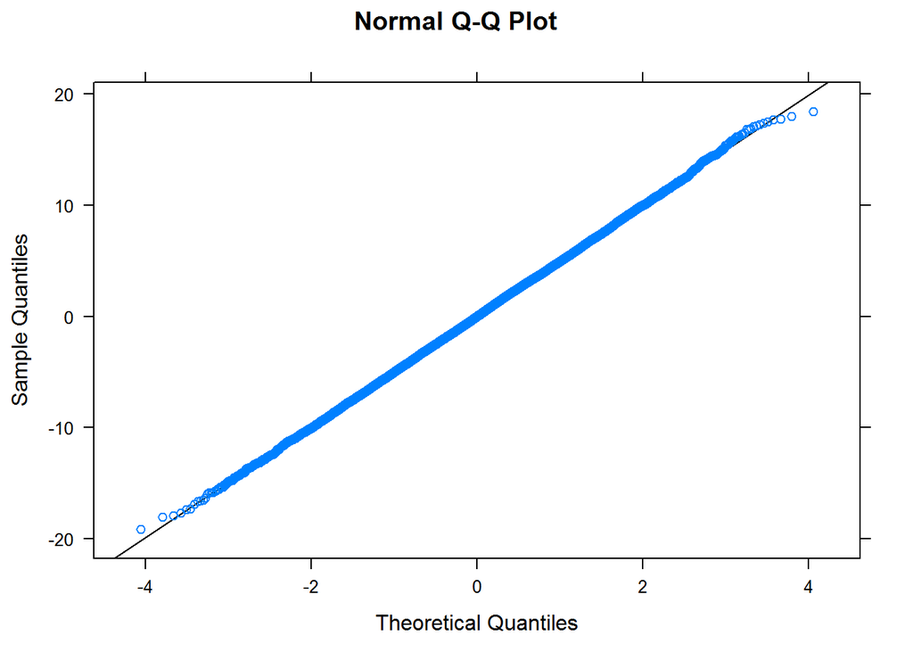

```r
# single variable qqplot
bn.fit.qqplot(gbn.fit$V)
```

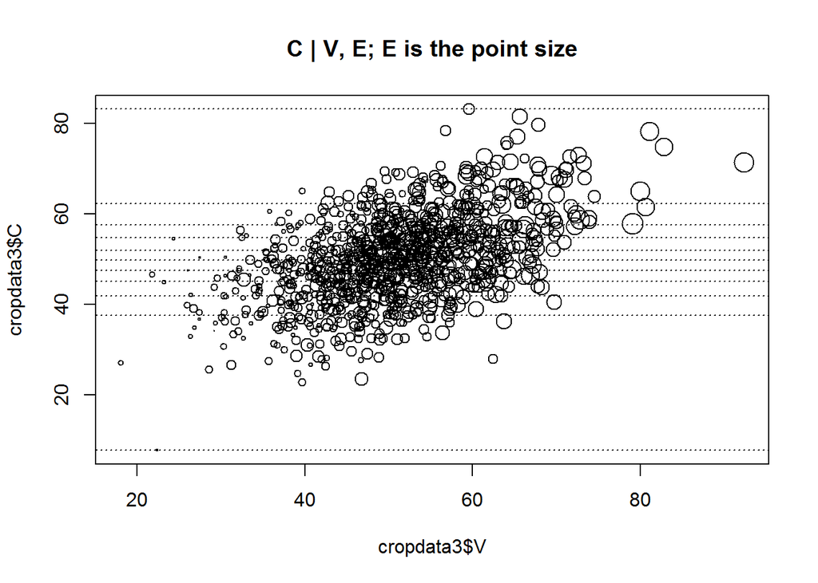

```r
set.seed(5678)
cropdata3 <- cpdist(gbn.bnlearn, nodes = c("E", "V", "C"),
                    evidence = TRUE, n = 1000)
plot(cropdata3$V, cropdata3$C, type = "n",
     main = "C | V, E; E is the point size")
cexlim <- c(0.1, 2.4)
cexE <- cexlim[1] + diff(cexlim) / diff(range(cropdata3$E)) *
                    (cropdata3$E - min(cropdata3$E))
points(cropdata3$V, cropdata3$C, cex = cexE)
cqa <- quantile(cropdata3$C, seq(0, 1, 0.1))
abline(h = cqa, lty = 3)
```

# 3. Hybrid Bayesian Networks

we would like to show that there are no theoretical reasons for distinguishing BNS with either discrete or continuous variables according to the phenomenon under investigation:

- we can mix discrete and continuous variables
- we can use any kind of distribution.

# 4. Theory and Algorithms for Bayesian Networks

In this chapter we will provide the theoretical foundations underpinning the classes of BNs we explored in Chapter 1 (**discrete BNs**), Chapter 2 (**GBNs**) and Chapter 3 (**hybrid BNs**). In particular, we will

- introduce the formal definition of a BN and its fundamental properties.
- show how these properties are at the base of BN learning and inference.

## 4.1 Conditional Independence and Graphical Separation

BNs are a class of graphical models, which allow an intuitive representation of the probabilistic structure of multivariate data using graphs. It consists of two parts.

- a **set of random variables** $X = {X_{1}, X_{2},..., X_{p}}$ describing the quantities of interest.
  - The multivariate probability distribution of $X$ is called the global distribution of the data,
  - the univariate ones associated with each $X_{i} \in X$ are called local distributions;
- a **directed acyclic graph** (DAG), denoted $G = (V, A)$.
  - Each node $v \in V$ is associated with one variable Xi.
  - The directed arcs $a\in A$ that connect them represent direct probabilistic dependencies
  - so if there is no arc connecting two nodes the corresponding variables are either independent or conditionally independent given a subset of the remaining variables.

### 4.1.1 Map

The link between the graphical separation (denoted `_||_G`) induced by the absence of a particular arc and probabilistic independence (denoted `_||_P` provides a direct and easily interpretable way to express the relationships between the variables.

Let M be the dependence structure of the probability distribution P of X, that is, the set of conditional independence relationships linking any triplet A, B, C of subsets of X.

- **D-map**: dependency map: A graph G is a dependency map (or D-map) of M if there is a one-to-one correspondence from the random variables in X to the nodes V of G.
- **I-map**: Independency map: A graph G is a independency map (or i-map) of M if there is a one-to-one correspondence from the nodes V of G to the random variables in X
- **perfect map**: A graph G is a dependency map and an independent map of M if there is a one-to-one correspondence between the random variables in X and the nodes V of G. In this case G is said to be faithful or isomorphic to M.

### 4.1.2 d-seperation

If A, B and C are three disjoint subsets of nodes in a DAG G (A -> B -> c), then C is said to d-separate A from B, denoted A `_||_G` B | C, if along every path between a node in A and a node in B there is a node v satisfying one of the following two conditions:

- v has converging arcs (i.e. **convergent connectoin**: there are two arcs pointing to v from the adjacent nodes in the path) and neither v nor any of its descendants (i.e. **divergent connectoin**: the nodes that can be reached from v) are in C.
- v is in C and does not have converging arcs.(i.e. **serial connection**)

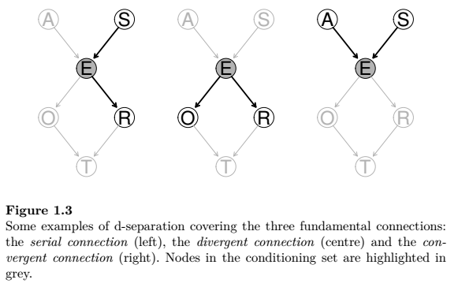

## 4.2 Bayesian Networks

Having defined a criterion to determine whether two nodes are connected or not in discussion of **Conditional Independence Tests** (1.4.1, 2.4.1) and **Network Scores** (section 1.4.2, 2.4.2), and how to map those connections (or the lack thereof) to the probability distribution of X in discussion of **d-seperation** (section 4.1.1, 4.1.2), we are now ready to introduce the `formal definition of Bayesian Networks`:

- Given a probability distribution P on a set of variables X, a DAG G = (X, A) is called a **Bayesian Network** and denoted B = (G, X) if and only if G is a minimal I-map of P, so that none of its arcs can be removed without destroying its I-mapness.

$Pr(x) = \prod_{i=1}^{p}{(X_i|\prod_{X_i})} = \prod_{i=1}^{p}{(X_i|X_i+1,...,X_p)}$

where: $\prod_{X_i}$ is the set of the parents of $X_i$. If $X_i$ has two or more parents it depends on their joint distribution,

### 4.2.1 Local Markov property

Each node $X_i$ is conditionally independent of its non-descendants (e.g., nodes $X_j$ for which there is no path from $X_i$ to $X_j$) given its parents.

The `conditionally independence relationship` highlights the fact that:

- parents are not completely independent from their children in the BN;
- a trivial application of Bayes' theorem to invert the direction of the conditioning shows how information on a child can change the distribution of the parent.

#### 4.2.1.1 [Random process](https://ocw.mit.edu/courses/electrical-engineering-and-computer-science/6-041-probabilistic-systems-analysis-and-applied-probability-fall-2010/video-lectures/lecture-16-markov-chains-i/):

- Bernoulli process: oryless, discrete time
- Poisson process: memoryless, continous time
- Markov chains: memory, dependence across time

Time-independent random process

| category | Bernoulli | Poisson |
| --- | --- | --- |
| Times of Arrival | discrette | continuous |
| Arrival Rate | probability $p$ p per trial | average # of events in an interval $\lambda$ per unit time |
| PMF of # of Arrival | Binomial distribution | Poisson distribution |
| Interarrival Time Distr | Geometric distribution | Exponential distribution |
| Time to k-th arrival | Pascal (negative binomial) distribution | Erlang distribution |
| Splitting | Bernoulli process | Poisson process: $p\lambda$, $(1-p)\lambda$ |
| Merging | Bernoulli process | Poisson process: $\lambda = \frac{\lambda_1}{\lambda_2 +\lambda_2}$ |

### 4.2.2 Equivalence classes

Two DAGs defined over the same set of variables belong to the same `equivalent classes` if and only if they have the same skeleton (i.e., the same underlying undirected graph) and the same v-structures. (i.e. $X_i \rightarrow X_j \rightarrow X_k$ and $X_i \rightarrow X_j \leftarrow X_k$)

- `v-structures`: A convergent connection $X_i \rightarrow X_k \leftarrow X_j$ is called a v-structure if there is no arc connecting $X_i$ and $X_j$. In addition, $X_k$ is often called the `collider node` and the connection is then called an `unshielded collider`, as opposed to a shielded collider in which either $X_i \rightarrow X_j$ or $X_i \leftarrow X_j$.
- `partially directed graph` (CPDAG): Following Theorem of `equivalence class`, not all arcs in this graph are directed; therefore, it is not a DAG because it is only partially directed.
  - `cpdag()`: can obtain completed partially directed graph from dag with cpdag function.
    - `compelled arc`: if disregarding the direction of an arc would result in one of its possible direction introducing cycles, such an arc is considered compelled and its original direction preserved in CPDAG. (i.e. $X_8 \rightarrow X_6$)
    - `incompelled arc`: the change of arc direction does not introduce any v-structure in the graph, as they are part only of serial (the former) or divergent connections (the latter). (i.e. $X_1 - X_4$, $X_2 - X_4$, $X_5 - X_7$)

```r
X <- paste("[X1][X3][X5][X6|X8][X2|X1][X7|X5][X4|X1:X2]",
      "[X8|X3:X7][X9|X2:X7][X10|X1:X9]", sep = "")
dag <- model2network(X)
skel <- skeleton(dag)
vstructs(dag)
```

```
##      X    Z     Y
## [1,] "X1" "X10" "X9"
## [2,] "X3" "X8"  "X7"
## [3,] "X2" "X9"  "X7"
```

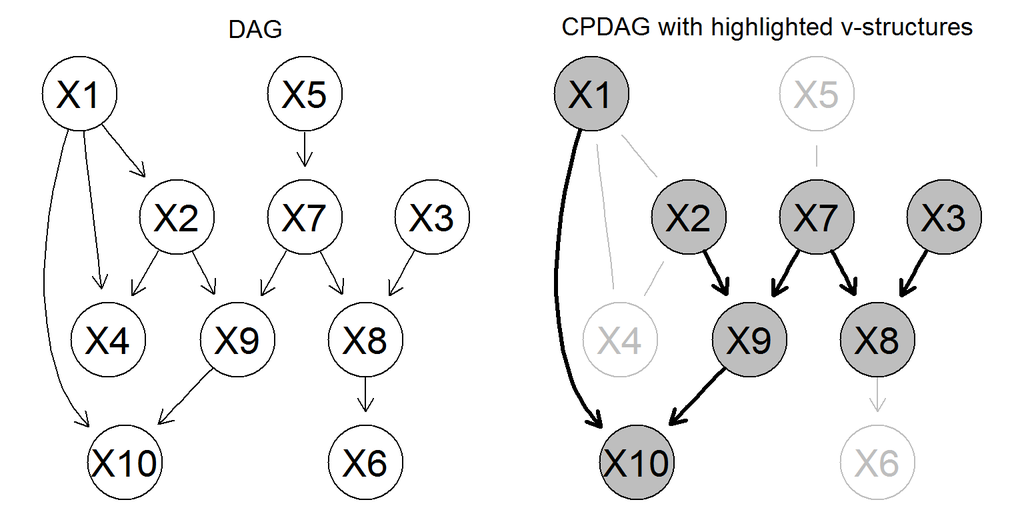

## 4.3 Markov Blanket

The Markov blanket of a node include all nodes in the v-structures that include that node, and without that node. Markov blanket of a node is the only knowledge needed to predict the behavior of that node and its children. the Markov blanket is he minimal subset of nodes we need to condition upon. The Markov blanket of a node A is the set consisting of:

- the parents of A,
- the children of A
- all the other nodes sharing a child with A.

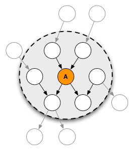

Markov Blanket in BN

### 4.3.1 Symmetry of Markov blankets

Symmetry of Markov blankets defines a symmetric relationship: if node A is in the Markov blanket of B, then B is in the Markov blanket of A.

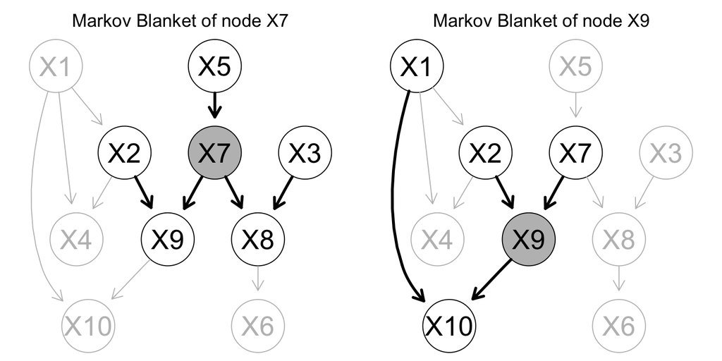

## 4.4 Moral Graphs

The moral graph is a representation of Markov network by converting BN via the idea of `v-structure` and `markov blanket`. It is constructed as follows:

- connecting the `non-adjacent nodes` in each v-structure with an undirected arc;
- ignoring the direction of the other arcs, effectively replacing them with `undirected arcs`.

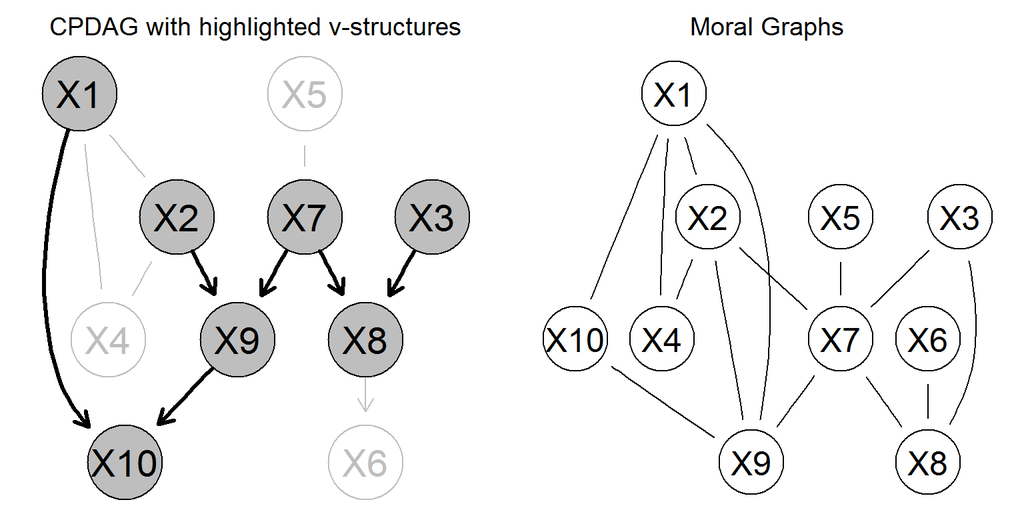

```r
vstructs(dag)
```

```
##      X    Z     Y
## [1,] "X1" "X10" "X9"
## [2,] "X3" "X8"  "X7"
## [3,] "X2" "X9"  "X7"
```

### 4.4.1 Uses

Moralisation has several uses.

- First, it provides a simple way to transform a BN into the corresponding `Markov network`, a graphical model using undirected graphs instead of DAGs to represent dependencies. These models have a long history in statistics, and have been studied in such classic monographs as Whittaker (1990) and Lauritzen (1996).
  - On the one hand, all dependencies are `explicitly` represented in a Markov network, even those that would be implicitly implied by v-structures in a BN.
  - On the other hand, the addition of undirected arcs makes the graph structure less informative, because we cannot tell that nodes that were parents in a v-structure are marginally independent when we are not conditioning on their common child.
- Second, moral graphs provide the foundation for exact inference on BNs through the junction tree algorithm, which will be introduced in Section 4.6.2.

Additional infomation:

- Probabilistic Model
  - Probabilistic Graphical Model
    - **Bayesian Network** (use DAG)
      - Static Bayesian Network
      - Dynamic Bayesian Network
        - Hidden Markov Model (generative)
    - **Markov Network** (uses undirected graph)
      - Markov Random Field (generative)
      - Conditional Random Field (discriminative)

## 4.5 Bayesian Network Learning

In the field of BNs, model selection and estimation are collectively known as `learning`, a name borrowed from artificial intelligence and machine learning. This workflow is inherently Bayesian. Consider a data set D and a BN $B = (G, X)$. If we denote the parameters of the global distribution of $X$ with $\Theta$, we can assume without loss of generality that $\Theta$ uniquely identifies $X$ in the parametric family of distributions chosen for modelling $D$ and write $B = (G, \Theta)$. BN learning, which maximizes Pr(B | D), is usually performed as a two-step process:

$$Bayesian Network Learning: Pr(B | D) \overset{B = (G, X)}{=} Pr(G, \Theta | D) \overset{Bayes' Rule}{=} Pr(G | D) \times Pr(\Theta | G, D)$$

$$Structure Learning: Pr(G|D) \overset{Bayes' Rule}{\propto} Pr(G)Pr(D|G) = Pr(G)\int Pr(G, \Theta | D) Pr(\Theta | G)d\Theta$$

1. structure learning by maximizing Pr($G | D$): learning the structure of the DAG.
2. parameter learning by maximizing Pr($\Theta | G, D$): learning the local distributions implied by the structure of the DAG learned in the previous step.

where:

- $D$: Data set;
- $B$: Bayesian Network, defined as $B = (G, X)$;
- $G$: DAG structure;
- $X$: the global distribution, defined as $x \sim X(\Theta)$;
- $\Theta$: the parameters set of the global distribution of $X$.

Both steps can be performed either as

- `unsupervised learning`: using the information provided by a data set,
- `supervised learning`: by interviewing experts in the fields relevant for the phenomenon being modelled.
- combining both approaches is common.

### 4.5.1 Structure Learning

Despite the (sometimes confusing) variety of theoretical backgrounds and terminology they can all be traced to only three approaches:

- constraint-based Algorithms
- score-based Algorithms
- hybrid Algorithms

All these structure learning algorithms operate under a set of common assumptions:

- `One node to one random variable`: There must be a one-to-one correspondence between the nodes in the DAG and the random variables in X; this means in particular that there must not be multiple nodes which are deterministic functions of a single variable.
- `conditional independencies between variables`: All the relationships between the variables in X must be conditional independencies, because they are by definition the only kind of relationships that can be expressed by a BN.
- Every combination of the possible values of the variables in X must represent `a valid, observable (even if really unlikely) event`. This assumption implies a strictly positive global distribution, which is needed to have uniquely determined Markov blankets and, therefore, a uniquely identifiable model. Constraint-based algorithms work even when this is not true, because the existence of a perfect map is also a sufficient condition for the uniqueness of the Markov blankets (Pearl, 1988).
- Observations are treated as independent realisations of the set of nodes. If some form of temporal or spatial dependence is present, it must be specifically accounted for in the definition of the network, as in dynamic Bayesian networks.

For more information check by `?bnlearn`

#### 4.5.1.1 Constraint-based Algorithms

Constraint-based structure learning algorithms are implemented in bnlearn in the `gs`, `iamb`, `fast.iamb` and `inter.iamb` functions. All these functions accept the following arguments:

- `x`, the data the network will be learned from;
- `whitelist` and `blacklist`, to force the inclusion or the exclusion of specific arcs from the network;
- `test`, the label of the conditional independence test to be used. It defaults to `"mi"` for discrete BNs and `"cor"` for GBNs;
- `alpha`, the type I error threshold for the test. It defaults to $\alpha = 0.05$, as is common in literature. Note that, regardless of the dimension of the BN, there is no need to apply any multiple testing adjustment to $\alpha$, because constraintbased learning algorithms are largely self-adjusting in that respect;
- `B`, the number of permutations for Monte Carlo tests;
- `debug`, which prints the sequence of tests performed by the learning algorithm. Setting it to `TRUE` may be useful both for understanding how structure learning works in practice, for debugging, and also to assess the swiftness of the learning algorithm. **Diagnosis is important**.

```r
head(cropdata1)
```

```
##      C    E    G    N    V    W
## 1 48.8 51.5 42.6 54.1 43.0 42.0
## 2 48.9 73.4 41.0 60.1 65.3 49.0
## 3 67.0 71.1 52.5 51.6 63.2 62.0
## 4 37.8 49.3 56.2 49.0 47.8 38.8
## 5 55.3 49.3 63.5 54.6 60.6 56.7
## 6 56.1 48.7 66.0 44.0 55.5 52.4
```

```r
bn.cor <- gs(cropdata1, test = "cor", alpha = 0.05)
bn.zf <- gs(cropdata1, test = "zf", alpha = 0.05)
bn.mc <- gs(cropdata1, test = "mc-cor", B = 1000)
bn.iamb <- iamb(cropdata1, test = "cor", alpha = 0.05)
bn.cor2 <- gs(cropdata1, test = "cor", alpha = 0.05,
            whitelist = c("V", "N"))

all.equal(bn.cor, bn.zf)
```

```
## [1] TRUE
```

```r
all.equal(bn.cor, bn.mc)
```

```
## [1] TRUE
```

```r
all.equal(bn.cor, bn.iamb)
```

```
## [1] TRUE
```

```r
# Diagnosis
# The small sample size seems to reduce the power of the tests, and the arc V -> N is missing from the DAG as a result. Therefore, we may wonder whether changing the conditional independence test to Fisher's Z test or to a Monte Carlo test may help in learning the correct structure.
ci.test("N", "V", test = "cor", data = cropdata1)
```

```
##
##  Pearson's Correlation
##
## data:  N ~ V
## cor = -0.05, df = 200, p-value = 0.5
## alternative hypothesis: true value is not equal to 0
```

```r
ci.test("N", "V", "C", test = "cor", data = cropdata1)
```

```
##
##  Pearson's Correlation
##
## data:  N ~ V | C
## cor = -0.2, df = 200, p-value = 0.009
## alternative hypothesis: true value is not equal to 0
```

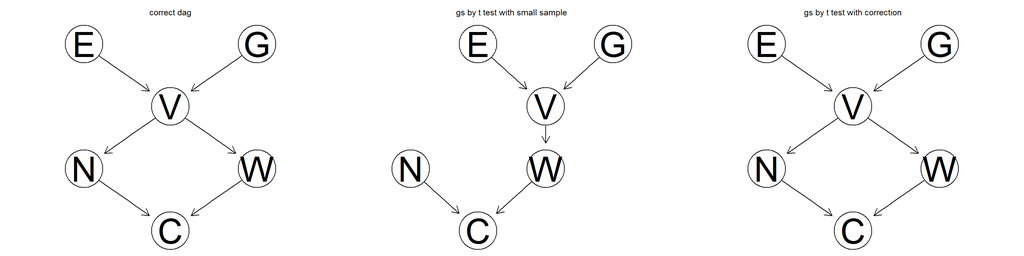

```r
par(mar = rep(0, 4))
par(mfrow = c(1, 3))
graphviz.plot(dag.bnlearn, main = "correct dag")
graphviz.plot(bn.cor, main = "gs by t test with small sample")
graphviz.plot(bn.cor2, main = "gs by t test with correction")
```

```r
# debug = TRUE, identify exactly which tests fail to detect the dependence between two node.
# warning: masive output
# gs(cropdata1, test = "cor", alpha = 0.05, debug = TRUE)
```

##### 4.5.1.1.1 Development of Constraint-based Algorithms

The `inductive Causation` (IC) algorithm (Verma and Pearl, 1991) provides a framework for learning the DAG structure of BNs using conditional independence tests. Inductive Causation Algorithm:

1. For each pair of nodes A and B in V search for set $S_{AB} \subset V$ V such that A and B are `independent` given $S_{AB}$ and $A, B \notin S_{AB}$. If there is no such a set, place an undirected arc between A and B.
2. For each pair of non-adjacent nodes A and B with a common neighbour C, check whether $C \in S_{AB}$. If this is not true, `set the direction` of the arcs A - C and C - B to $A \rightarrow C$ and $C \leftarrow B$.
3. `Set the direction` of arcs which are still undirected by applying recursively the following two rules:
   1. if A is adjacent to B and there is a strictly directed path from A to B then set the direction of A - B to $A \rightarrow B$;
   2. if A and B are not adjacent but $A \rightarrow C$ and $C \leftarrow B$, then change the latter to $C \rightarrow B$.
4. Return the resulting CPDAG.

A major problem of the IC algorithm is that the first two steps cannot be applied in the form described in Algorithm 4.1 to any real-world problem due to the exponential number of possible conditional independence relationships. This has led to the development of improved algorithms such as:

Labels of the algorithms implemented in bnlearn.

[output not shown]

##### 4.5.1.1.2 Conditional Independence Tests and Distribution

For all the tests above, the null hypothesis of independence can be tested using:

- the **asymptotic $\chi^2_{(R-1)(C-1)L}$ distribution**, which is very `fast` to compute but requires an `adequate sample size to be accurate`;
- the **Monte Carlo permutation approach** or the faster, **sequential Monte Carlo permutation approaches** described in Edwards (2000). Both approaches ensure that the tests are `unbiased`, and that they are valid even for small sample sizes. However, they are `computationally expensive`;
- the **semiparametric $\chi^2$ distribution** described in Tsamardinos and Borboudakis (2010), which represents a `compromise` between the previous two approaches.

Labels of the conditional independence tests for discrete case implemented in bnlearn. (4.1)

| `test` | Asymptotic $\chi^2$ distribution | Monte Carlo permutation approach | Sequential Monte Carlo permutation approach | Semiparametric $\chi^2$ distribution | asymptotic normal test |
| --- | --- | --- | --- | --- | --- |
| (*categorical variables*) |  |  |  |  |  |
| mutual information ($G^2$) | `"mi"` (default) | `"mc-mi"` | `"smc-mi"` | `"sp-mi"` | - |
| Pearson’s $\chi^2$ | `"x2"` | `"mc-x2"` | `"smc-x2"` | `"sp-x2"` | - |
| mutual information (shrinkage) | `"mi-sh"` | - | - | - | - |
| (*ordered factors*) |  |  |  |  |  |
| Jonckheere-Terpstra | - | `mc-jt` | `smc-jt` | - | `jt` |

Labels of the conditional independence tests for GBNs and hybrid case implemented in bnlearn. (4.2)

| `test` | Exact distribution | Asymptotic $\chi^2$ distribution | Monte Carlo permutation approach | Sequential Monte Carlo permutation approach |
| --- | --- | --- | --- | --- |
| (*normal variables*) |  |  |  |  |
| t test | `"cor"` (default) | - | `"mc-cor"` | `"smc-xcor"` |
| Fisher’s Z test | - | `"zf"` | `"mc-zf"` | `"smc-zf"` |
| mutual information | - | `"mi-g"` | `"mc-mi-g"` | `"smc-mi-g"` |
| mutual information (shrinkage) | - | `"mi-g-sh"` | - | - |
| (*mixed discrete and normal variables*) |  |  |  |  |
| mutual information |  | `mi-cg` |  |  |

#### 4.5.1.2 score-based Algorithms

In score-based algorithms, there are two function `hc` and `tabu`.

Each candidate BN is assigned a network score reflecting its goodness of fit, which the algorithm then attempts to maximise. Some examples from this class of algorithms are:

- `greedy search` algorithms such as hill-climbing with random restarts or tabu search (Bouckaert, 1995). These algorithms explore the search space starting from a network structure (usually without any arc) and adding, deleting or reversing one arc at a time until the score can no longer be improved (see Algorithm 4.2);
- `genetic` algorithms, which mimic natural evolution through the iterative selection of the “fittest” models and the hybridisation of their characteristics (Larra?aga et al., 1997). In this case the search space is explored through the crossover (which combines the structure of two networks) and mutation (which introduces random alterations) stochastic operators;
- `simulated annealing` (Bouckaert, 1995). This algorithm performs a stochastic local search by accepting changes that increase the network score and, at the same time, allowing changes that decrease it with a probability inversely proportional to the score decrease.

Labels of the score for discrete case implemented in bnlearn.

| `score` | multinomial | Information Criterion | Bayesian Dirichlet posterior density | Dirichlet posterior density |
| --- | --- | --- | --- | --- |
| Log-Likelihood | `"loglik"` | - | - | - |
| Akaike | - | `"aic"` | - | - |
| Bayesian | - | `"bic"` | - | - |
| equivalent | - | - | `"bde"` | - |
| sparse | - | - | `"bds"` | - |
| Jeffrey's prior | - | - | `"bdj"` | - |
| mixtures of experimental and observational data | - | - | `"mbde"` | - |
| locally averaged | - | - | `"bdla"` | - |
| K2 | - | - | - | `"k2"` |

Labels of the score for GBNs and hybrid case implemented in bnlearn.

| `score` | multivariate Gaussian | Information Criterion | Gaussian posterior density | conditional linear Gaussian |
| --- | --- | --- | --- | --- |
| (*normal variables*) | - | - | - | - |
| log-likelihood | `"loglik-g"` | - | - | - |
| Akaike | - | `"aic-g"` | - | - |
| Bayesian | - | `"bic-g"` | - | - |
| equivalent | - | - | `"bge"` | - |
| (*mixed discrete and normal variables*) | - | - | - | - |
| log-likelihood | - | - | - | `"loglik-cg"` |
| corresponding Akaike | - | `"aic-cg"` | - | - |
| corresponding Bayesian | - | `"bic-cg"` | - | - |

Neither `hc` nor `tabu` are able to learn the true DAG. There are many reasons for get stuck at a local maximum:

- unfavourable choice for the starting point of the search.
- not complete

```r
learned <- hc(survey, score = "bic")
modelstring(learned)
score(learned, data = survey, type = "bic")

survey.dag <- model2network("[A][S][E|A:S][O|E][R|E][T|O:R]")
learned.start <- hc(survey, score = "bic", start = survey.dag)
modelstring(learned.start)
all.equal(cpdag(learned), cpdag(learned.start))

# start with a randomly generated graph
set.seed(1234)
learned <- hc(survey, score = "bic", start = random.graph(names(survey)))

# debug = TRUE, identify exactly which tests fail to detect the dependence between two node.
# warning: masive output
#learned <- hc(survey, score = "bic", debug = TRUE)
```

[output not shown]

##### 4.5.1.2.1 Development of score-based Algorithms

Example of greedy search algorithm, Hill-Climbing Algorithm:

1. Choose a network structure G over V, usually (but not necessarily) empty.
2. Compute the score of G, denoted as $Score_G = Score(G)$.
3. Set $maxscore = Score_G$.
4. Repeat the following steps as long as maxscore increases:
   1. for every possible arc addition, deletion or reversal not resulting in a cyclic network:
      1. compute the score of the modified network $G^*$, $Score_{G^*} = Score(G^*)$:
      2. if $Score_{G^*} > Score_G$, set $G = G^*$ and $Score_G = Score_{G^*}$.
   2. update maxscore with the new value of ScoreG. 5. Return the DAG G.

#### 4.5.1.3 hybrid Algorithms

Hybrid learning algorithms combine constraint-based and score-based algorithms to offset the respective weaknesses and produce reliable network structures in a wide variety of situations. Both these algorithms are based on two steps, called:

1. `restrict`: results in a smaller and more regular search space.(in `rsmax2()`, pass with a character string for the constraint-based or local search algorithm to be used in the “restrict” phase.)
2. `maximise`: seeks the network that maximises a given score function. (in `rsmax2()`, pass with a character string for the score-based algorithm to be used in the “maximize” phase)

| Algorithms | Method | Description |
| --- | --- | --- |
| `mmhc` | Max-Min Hill-Climbing | Restrict and Maximise are performed only once; |
| `mmpc` | Max-Min Parents and Children | heuristic is used to learn the candidate sets $C_i$ and a hill-climbing greedy search to find the optimal network. |
| `rsmax2` | more general 2-phase Restricted Maximization | implements a single-iteration variant of the Sparse Candidate algorithm; the algorithms used in each step can be specified independently. |

```r
learn.mmhc <- mmhc(survey)
# equivalent to the more general rsmax2 function when the restrict argument is set to "mmpc" and the maximize argument is set to "hc".
learn.rsmax2 <- rsmax2(survey, restrict = "mmpc", maximize = "hc")
all.equal(learn.rsmax2, learn.mmhc)
```

```
## [1] TRUE
```

```r
learn.mmpc <- mmpc(survey)
rsmax2(survey,
       restrict = "si.hiton.pc", restrict.args = list(test = "x2"),
       maximize = "tabu", maximize.args = list(score = "bde", iss = 5))
```

##### 4.5.1.3.1 Development of hybrid Algorithms

The two best-known members of this family are the Sparse Candidate algorithm (`SC`) by Friedman et al. (1999) and the Max-Min Hill-Climbing algorithm (`MMHC`) by Tsamardinos et al. (2006).

Sparse Candidate Algorithm:

1. Choose a network structure G over V, usually (but not necessarily) empty.
2. Repeat the following steps until convergence:
   1. restrict: select a set Ci of candidate parents for each node $X_i \in V$, which must include the parents of $X_i$ in G;
   2. maximise: find the network structure G??? that maximises $Score_{G^*}$ among the networks in which the parents of each node $X_i$ are included in the corresponding set $C_i$;
   3. set $G = G^*$.
3. Return the DAG G.

### 4.5.2 Parameter Learning

Once the structure of the BN has been learned from the data, the task of estimating and updating the parameters of the global distribution is greatly simplified by the decomposition into local distributions. Two approaches are common in literature:

- `maximum likelihood estimation`
- `Bayesian estimation`

Examples of both were covered in Section 1.4 (for discrete BNs) and Section 2.4 (for GBNs).

## 4.6 Bayesian Network Inference

The process of Bayesian Network Inference:

- `inference`: The techniques used to obtain answers to the questions about the nature of the data that go beyond the mere description of the behaviour of the observed sample.
- `probabilistic reasoning` or `belief updating`: the process of answering these questions in BNs
- `query`: the questions themselves.

### 4.6.1 Probabilistic Reasoning and Evidence

In practice, probabilistic reasoning on BNs works in the framework of Bayesian statistics and focuses on the computation of posterior probabilities or densities. For example, suppose we have learned a BN B with structure $G$ and parameters $\Theta$, under one of the distributional assumptions we explored in Chapters 1, 2 and 3. Subsequently, we want to use B to investigate the effects of a new piece of evidence E using the knowledge encoded in B, that is, to investigate the posterior distribution $Pr(X | E, B) = Pr(X | E, G, \Theta)$.

The two most common kinds of evidence are:

- `hard evidence`: an instantiation of one or more variables in the network.
- `soft evidence`: a new distribution for one or more variables in the network. Since both the network structure and the distributional assumptions are treated as fixed, soft evidence is usually specified as a new set of parameters,

we will focus on two type of queries:

- `conditional probability` (CPQ): it is concerned with the distribution of a subset of variables $Q = {X_{j1},..., X_{jl}}$ given some hard evidence E on another set $X_{i1},..., X_{ik}$ of variables in X. The two sets of variables can be assumed to be disjoint. Its application could be:
  - it can be used to assess the interaction between two sets of experimental design factors for a trait of interest; the latter would be considered as the hard evidence E, while the former would play the role of the set of query variables Q.
  - the odds of an unfavourable outcome Q can be assessed for different sets of hard evidence $E_1, E_2,..., E_m$.
- `maximum a posteriori` (MAP) queries, also known as most `probable explanation` (MPE) queries. It is concerned with finding the configuration $q^*$ of the variables in Q that has the highest posterior probability (for discrete BNs) or the maximum posterior density (for GBNs and hybrid BNs). Its application:
  - imputing missing data from partially observed hard evidence, where the variables in Q are not observed and are to be imputed from those in E,
  - comparing $q^*$ with the observed values for the variables in Q for completely observed hard evidence.

### 4.6.2 Algorithms for Belief Updating

Algorithms for belief updating can be classified either as:

| Inference algorithms | Explanation | Appropriate uses |
| --- | --- | --- |
| Exact | combine repeated applications of `Bayes' theorem` with local computations | simple networks |
| Approximate | use `Monte Carlo` simulations to sample from the global distribution | complex networks |

#### 4.6.2.1 Exact inference algorithms

Exact inference algorithms combine repeated applications of `Bayes' theorem` with local computations to obtain exact values $Pr(Q | E, G, \Theta)$. Due to their nature, such algorithms are feasible only for small or very `simple networks, such as trees and polytrees`. In the worst case, their computational complexity is exponential in the number of variables.

```
* variable elimination
* belief updates based on junction trees.
```

A `junction tree` is a transformation of the moral graph of B in which the original nodes are clustered to reduce any network structure into a tree. Junction Tree Clustering Algorithm is the following:

1. Moralise: create the moral graph of the BN B as explained in Section 4.4.
2. Triangulate: break every cycle spanning 4 or more nodes into subcycles of exactly 3 nodes by adding arcs to the moral graph, thus obtaining a triangulated graph.
3. Cliques: identify the cliques $C_1,..., C_k$ of the triangulated graph, i.e., maximal subsets of nodes in which each element is adjacent to all the others.
4. Junction Tree: create a tree in which each clique is a node, and adjacent cliques are linked by arcs. The tree must satisfy the running intersection property: if a node belongs to two cliques Ci and Cj, it must be also included in all the cliques in the (unique) path that connects Ci and Cj.
5. Parameters: use the parameters of the local distributions of B to compute the parameter sets of the compound nodes of the junction tree.

#### 4.6.2.2 Approximate inference algorithms

Approximate inference algorithms use `Monte Carlo` simulations to sample from the global distribution of X and thus estimate $Pr(Q | E, G, \Theta)$.

- `cpquery()`: Perform conditional probability queries.
  - `method`: a character string, the method used to perform the conditional probability query.
    - `method = "ls"`: logic sampling (default)
    - `method = "lw"`: likelihood weighting are implemented.

##### 4.6.2.2.1 Logic Sampling Algorithm

`Logic Sampling Algorithm` can be very inefficient if $Pr(E)$ is small, because most particles will be discarded without contributing to the estimation of $Pr(Q | E, G, \Theta)$.

1. Order the variables in X according to the topological partial ordering implied by G, say $X_{(1)} \prec X_{(2)} \prec... \prec X{(p)}$.
2. Set $n_E = 0$ and $n_{E,q} = 0$.
3. For a suitably large number of samples $x = (x_1,..., x_p)$:
   1. generate $x_{(i)}$, $i = 1,..., p$ from $X_{(i)} |\Pi _{X_{(i)}}$ taking advantage of the fact that, thanks to the topological ordering, by the time we are considering Xi we have already generated the values of all its parents $\Pi_{X_{(i)}}$;
   2. if x includes E, set $n_E = n_E + 1$;
   3. if x includes both $Q = q$ and $E$, set $n_{E,q} = n_{E,q} + 1$.
4. Estimate $Pr(Q | E, G, \Theta)$ with $n_{E,q}/n_E$.
- `rbn()`: sample random observations from a BN, which takes a bn.fit object and the number of samples to generate as arguments.

```r
# Logic Sampling Algorithm, method = "ls"
cpquery(bn, event = (S == "M") & (T == "car"),
          evidence = (E == "high"), n = 10^6)
```

```
## [1] 0.3430287
```

```r
# equivalent step through Logic Sampling Algorithm
set.seed(123)
particles <- rbn(bn, 10^6)
partE <- particles[(particles[, "E"] == "high"), ]
nE <- nrow(partE)
partEq <- partE[(partE[, "S"] == "M") & (partE[, "T"] == "car"), ]
nEq <- nrow(partEq)
nEq/nE
```

```
## [1] 0.3432038
```

##### 4.6.2.3.2 Likelihood Weighting Algorithm

`Likelihood weighting` algorithm is an improvement over logic sampling with application of importance sampling. all the particles generated by likelihood weighting include the evidence E by design. However, this means that we are not sampling from the original BN any more, but we are sampling from a second BN in which all the nodes $X_{i1},..., X_{ik}$ in $E$ are fixed. This network is called the `mutilated network`.

Likelihood Weighting Algorithm:

1. Order the variables in X according to the topological ordering implied by G, say $X_{(1)} \prec X_{(2)} \prec... \prec X_{(p)}$. 2. Set $w_E = 0$ and $w_{E,q} = 0$.
2. For a suitably large number of samples $x = (x_1,..., x_p)$:
   1. generate $x_{(i)}$, $i = 1,..., p$ from $X_{(i)} | \Pi_{X_{(i)}$ using the values $e_1,..., e_k$ specified by the hard evidence $E$ for $X_{i1},..., X_{ik}$.
   2. compute the weight $w_x = \Pi Pr(X_i^* = e^* | \Pi X_{i^*})$
   3. set $w_E = w_E + w_x$;
   4. if $x$ includes $Q = q$, set $w_{E,q} = w_{E,q} + w_x$.
3. Estimate $Pr(Q | E, G, \Theta)$ with $w_{E,q}/w_E$.

```r
# Likelihood Weighting Algorithm, method = "lw"
set.seed(678)
cpquery(bn, event = (S == "M") & (T == "car"),
          evidence = list(E = "high"), method = "lw")
```

```
## [1] 0.3483792
```

```r
# equivalent step through Likelihood Weighting Algorithm
mutbn <- mutilated(bn, list(E = "high"))
particles <- rbn(bn, 10^6)
partQ <- particles[(particles[, "S"] == "M") & (particles[, "T"] == "car"), ]
nQ <- nrow(partQ)
w <- logLik(bn, particles, nodes = "E", by.sample = TRUE)
wEq <- sum(exp(w[(particles[, "S"] == "M") & (particles[, "T"] == "car")]))
wE <- sum(exp(w))
wEq/wE
```

```
## [1] 0.341512
```

## 4.7 Causal Bayesian Networks

The existence of equivalence classes of networks indistinguishable from a probabilistic point of view provides a simple proof that `arc directions are not indicative of causal effects`. This is the reason why building a BN from expert knowledge in practice codifies known and expected causal relationships for a given phenomenon. However, from an `intuitive point of view`, it can be argued that `a "good" BN should represent the causal structure of the data` it is describing. Such BNs are usually `fairly sparse`, and their interpretation is at the same time `clear and meaningful`, as explained by Pearl (2009) in his book on `causality`:

```
It seems that if conditional independence judgments are byproducts of stored causal relationships, then tapping and representing those relationships directly would be a more natural and more reliable way of expressing what we know or believe about the world. This is indeed the philosophy behind causal BNs.
```

In particular, three additional `assumptions` are needed for presents significant challenges by Learning such causal models, especially from observational data, :

- each variable $X_i \in X$ is `conditionally independent` of its non-effects, both direct and indirect, given its direct causes. This assumption is called the causal Markov assumption, and represents the causal interpretation of the local Markov property;
- there must exist a `DAG` which is `faithful` to the `probability distribution P of X`, so that the only dependencies in P are those arising from d-separation in the DAG;
- there must be `no latent variables` (unobserved variables influencing the variables in the network) acting as confounding factors. Such variables may induce spurious correlations between the observed variables, thus introducing bias in the causal network. Even though this is often listed as a separate assumption, it is really a corollary of the first two: the presence of unobserved variables violates the faithfulness assumption (because the network structure does not include them) and possibly the causal Markov property (if an arc is wrongly added between the observed variables due to the influence of the latent one).

`Issue` of causality and solution:

- These assumptions are `difficult to verify in real-world settings`, as the set of the potential confounding factors is not usually known. At best, we can address this issue, along with selection bias, by implementing a carefully planned experimental design.
- When the `sample size is small` there may also be several non-equivalent BNs fitting the data equally well. Therefore, in general we are not able to identify a single, “best”, causal BN but rather a small set of likely causal BNs that fit our knowledge of the data.

### 4.7.1 create latent variables

An example of the bias introduced by the presence of a latent variable was illustrated by Edwards (2000, page 113) using the marks data. Edwards noted that the students apparently belonged to two groups (which we will call A and B) with substantially different academic profiles. He then assigned each student to one of those two groups using the EM algorithm to impute group membership as a latent variable (LAT). The EM algorithm assigned the first 52 students (with the exception of number 45) to belong to group A, and the remainder to group B.

```r
data(marks)
head(marks)
```

```
##   MECH VECT ALG ANL STAT
## 1   77   82  67  67   81
## 2   63   78  80  70   81
## 3   75   73  71  66   81
## 4   55   72  63  70   68
## 5   63   63  65  70   63
## 6   53   61  72  64   73
```

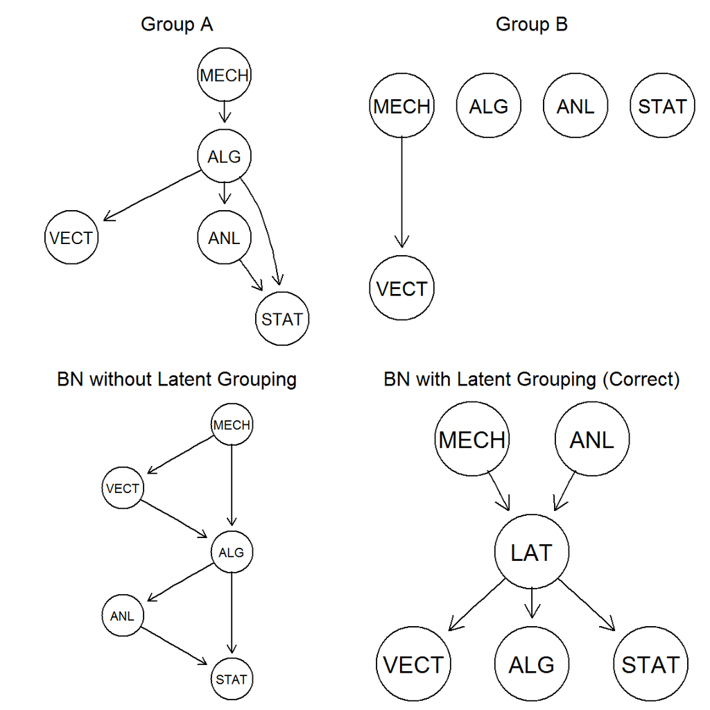

```r
latent <- factor(c(rep("A", 44), "B", rep("A", 7), rep("B", 36)))
dmarks <- discretize(marks, breaks = 2, method = "interval")

marks1 <- hc(marks[latent == "A", ])
marks2 <- hc(marks[latent == "B", ])
marks3 <- hc(marks)
marks4 <- hc(cbind(dmarks, LAT = latent))

par(mar = rep(0, 4))
par(mfrow = c(2, 2))
graphviz.plot(marks1, main = "Group A")
graphviz.plot(marks2, main = "Group B")
graphviz.plot(marks3, main = "BN without Latent Grouping")
graphviz.plot(marks4, main = "BN with Latent Grouping (Correct)")
```